# Figure 6d: `WT` NeRh50 maximum amplitudes and decay rate constants for representative SSME transient currents recorded at pH5-pH8

Manuscript figure 6d shows `WT` maximum amplitude and decay rate constant variation for representative SSME transient currents recorded at pH5-pH8 (figure 6d).

## The Dataset

```r
DT::datatable(dfms$dfm_6d, options=list(pageLength=5))
```

Table 1: Maximum amplitude and decay rate constant for representative SSME transient currents recorded at pH5-pH8 (figure 6d).

|  | pH | sheet | exptID | label | amplitude | decayrate |
| --- | --- | --- | --- | --- | --- | --- |
| 1 | pH5 | NeRh50 LPR 10 N1 | 2019-02-27-0006 | NeRh50 LPR 10 200 mM pH5 N1 M1 | 0.935 |  |
| 2 | pH5 | NeRh50 LPR 10 N1 | 2019-02-27-0007 | NeRh50 LPR 10 200 mM pH5 N1 M2 | 0.862 | 38.83 |
| 3 | pH5 | NeRh50 LPR 10 N1 | 2019-02-27-0008 | NeRh50 LPR 10 200 mM pH5 N1 M3 | 0.706 | 35.71 |
| 4 | pH5 | NeRh50 LPR 10 N2 | 2019-02-27-0022 | NeRh50 LPR 10 200 mM pH5 N2 M1 | 1.162 |  |
| 5 | pH5 | NeRh50 LPR 10 N2 | 2019-02-27-0023 | NeRh50 LPR 10 200 mM pH5 N2 M2 | 1.226 |  |
| 6 | pH5 | NeRh50 LPR 10 N2 | 2019-02-27-00024 | NeRh50 LPR 10 200 mM pH5 N2 M3 | 1.119 | 53.69 |
| 7 | pH5 | NeRh50 LPR 10 N3 | 2019-02-28-00012 | NeRh50 LPR 10 200 mM pH5 N3 M3 | 0.497 | 61.8 |
| 8 | pH6 | NeRh50 LPR 10 N1 | 2019-02-27-0010 | NeRh50 LPR 10 200 mM pH6 N1 M1 | 1.063 | 35.33 |
| 9 | pH6 | NeRh50 LPR 10 N1 | 2019-02-27-0011 | NeRh50 LPR 10 200 mM pH6 N1 M2 | 0.954 | 36.5 |
| 10 | pH6 | NeRh50 LPR 10 N3 | 2019-02-28-0013 | NeRh50 LPR 10 200 mM pH6 N3 M1 | 0.807 | 40.06 |

[output cut: 20 more lines]

### Downloads

- download data

## The Models

We use linear models for amplitude and decay rate as dependent variables, with pH as the independent factor, checking fit in Figure 1.

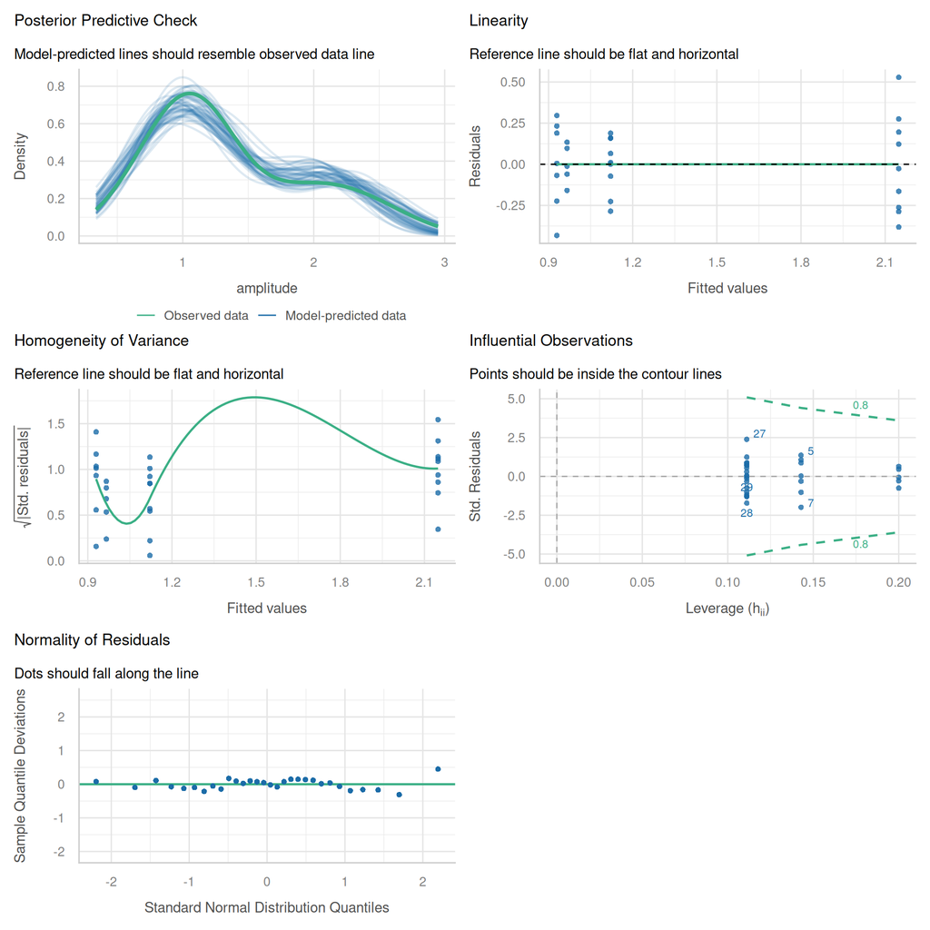

(a) `amplitude ~ pH`

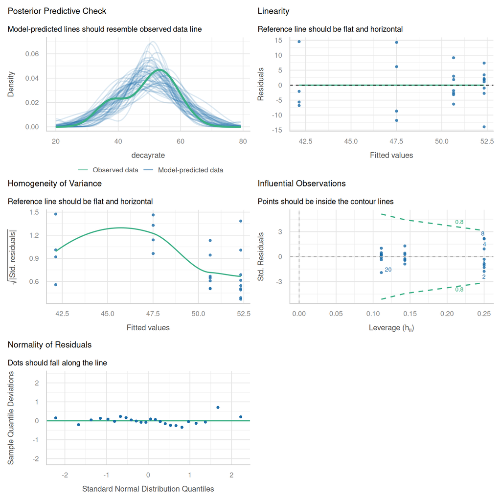

(b) `decayrate ~ pH`

Figure 1: Diagnostic plots for linear model fits of `amplitude ~ group` and `decayrate ~ group`. The heteroscadicity spline is odd, but the datapoints are not concerning. There is no strong evidence of non-normality of residuals.

```r
# Fit the models
model6d_amp_lm <- lm(amplitude ~ pH, data=dfms$dfm_6d)
model6d_k_lm <- lm(decayrate ~ pH, data=dfms$dfm_6d)

# Check model fit
performance::check_model(model6d_amp_lm)
performance::check_model(model6d_k_lm)
```

As the model fit is acceptable, we estimate contrasts in Table 2.

```r
EMM <- emmeans::emmeans(model6d_amp_lm, ~ pH)
confint(emmeans::contrast(EMM, "pairwise", adjust="sidak")) |>
  kableExtra::kbl(digits=3) |>
  kableExtra::kable_styling(
    bootstrap_options = c("hover", "responsive")
  )
EMM <- emmeans::emmeans(model6d_k_lm, ~ pH)
confint(emmeans::contrast(EMM, "pairwise", adjust="sidak")) |>
  kableExtra::kbl(digits=3) |>
  kableExtra::kable_styling(
    bootstrap_options = c("hover", "responsive")
  )
```

Table 2: Contrasts for model fits, with Sidak adjustment. Not all contrasts include zero in the 95% confidence interval estimate.

(a) Maximum amplitude

| contrast | estimate | SE | df | lower.CL | upper.CL |
| --- | --- | --- | --- | --- | --- |
| pH5 - pH6 | -0.036 | 0.138 | 26 | -0.428 | 0.355 |
| pH5 - pH7 | -0.192 | 0.118 | 26 | -0.529 | 0.146 |
| pH5 - pH8 | -1.219 | 0.118 | 26 | -1.556 | -0.882 |
| pH6 - pH7 | -0.155 | 0.131 | 26 | -0.529 | 0.218 |
| pH6 - pH8 | -1.182 | 0.131 | 26 | -1.556 | -0.809 |
| pH7 - pH8 | -1.027 | 0.111 | 26 | -1.343 | -0.712 |

(b) Decay rate

| contrast | estimate | SE | df | lower.CL | upper.CL |
| --- | --- | --- | --- | --- | --- |
| pH5 - pH6 | 5.368 | 5.451 | 20 | -10.536 | 21.271 |
| pH5 - pH7 | -3.140 | 4.832 | 20 | -17.236 | 10.957 |
| pH5 - pH8 | -4.824 | 4.632 | 20 | -18.339 | 8.691 |
| pH6 - pH7 | -8.507 | 4.832 | 20 | -22.604 | 5.590 |
| pH6 - pH8 | -10.191 | 4.632 | 20 | -23.706 | 3.324 |
| pH7 - pH8 | -1.684 | 3.885 | 20 | -13.018 | 9.650 |

For decay rate constant, all contrasts include zero in the 95% confidence interval, so we conclude that there are no differences in decay rate constant for each pH condition. There are contrasts that do not include zero for the maximum amplitude data, but only for those contrasts involving `pH8`.

## The Figures

We plot the data, indicating P-values for the contrasts in Figure 2.

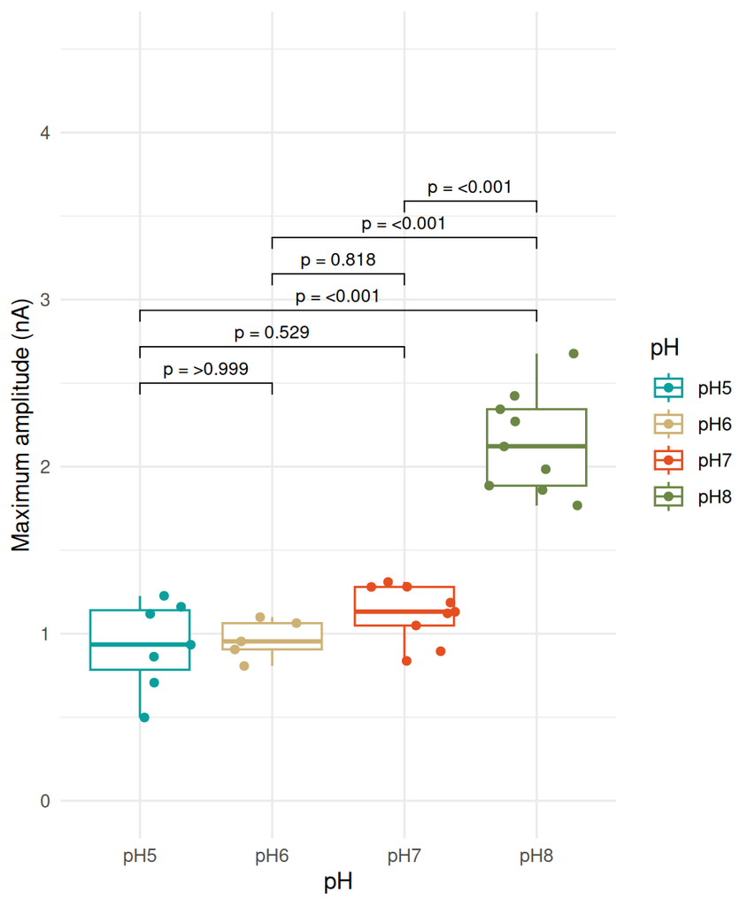

(a) Figure 6d, maximum amplitude

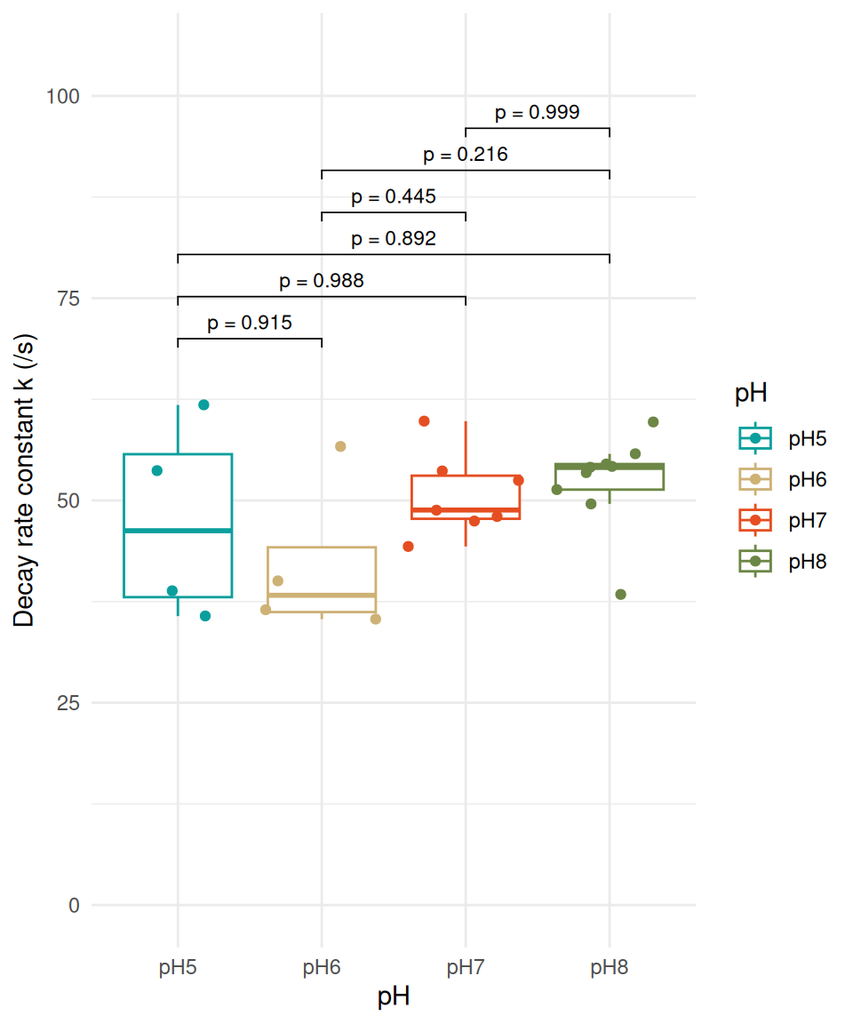

(b) Figure 6d, decay rate

Figure 2: Maximum amplitude and decay rate constant for four pH regimes.

```r
# Get p-values, accounting for heteroscedasticity and multiple testing
# Also generate group1 and group2 columns
EMM_amp <- as.data.frame(pairs(emmeans::emmeans(model6d_amp_lm, ~ pH),
                               adjust="sidak")) |>
  tidyr::separate(contrast, into=c("group1", "group2"), sep=" - ") |>
  dplyr::mutate(y.position=2.5) |>
  rstatix::add_significance()

EMM_k <- as.data.frame(pairs(emmeans::emmeans(model6d_k_lm, ~ pH),
                               adjust="sidak")) |>
  tidyr::separate(contrast, into=c("group1", "group2"), sep=" - ") |>
  dplyr::mutate(y.position=70) |>
  rstatix::add_significance()

p6d_amp <- ggplot2::ggplot(dfms$dfm_6d,
                           ggplot2::aes(x=pH, y=amplitude, color=pH)) +
  ggplot2::geom_boxplot(outlier.shape = NA) +
  ggplot2::geom_jitter() +
  ggplot2::labs(y="Maximum amplitude (nA)") +
  ggplot2::ylim(0, 4.5) +
  ggplot2::theme_minimal() +
  ggpubr::stat_pvalue_manual(EMM_amp,
                             label="p = {scales::pvalue(p.value)}",
                             size=3, step.increase=0.1)

p6d_k <- ggplot2::ggplot(dfms$dfm_6d,
                         ggplot2::aes(x=pH, y=decayrate, color=pH)) +
  ggplot2::geom_boxplot(outlier.shape = NA) +
  ggplot2::geom_jitter() +
  ggplot2::labs(y="Decay rate constant k (/s)") +
  ggplot2::ylim(0, 105) +
  ggplot2::theme_minimal() +
  ggpubr::stat_pvalue_manual(EMM_k,
                             label="p = {scales::pvalue(p.value)}",
                             size=3, step.increase=0.15)

p6d_amp
p6d_k

# Write figures to file (commented out for webpage)
#ggplot2::ggsave("assets/images/fig6d_WT_maximum_amplitude.pdf", p6d_amp)
#ggplot2::ggsave("assets/images/fig6d_WT_maximum_amplitude.png", p6d_amp)
#ggplot2::ggsave("assets/images/fig6d_WT_decay_rate_constant.png", p6d_k)
#ggplot2::ggsave("assets/images/fig6d_WT_decay_rate_constant.pdf", p6d_k)
```

### Downloads

- Download maximum amplitude figure as .pdf
- Download maximum amplitude figure as .png
- Download decay rate constant figure as .pdf
- Download decay rate constant figure as .png